# PRA 2: Neteja, validació i anàlisi de les dades

Álvaro Díaz i David Leiva

23/12/2020

# 1 Detalls de l’activitat

## 1.1 Presentació

En aquesta pràctica s’elabora un cas pràctic orientat a aprendre a identificar les dades rellevants per un projecte analític i usar les eines d’integració, neteja, validació i anàlisi d’aquestes.

## 1.2 Competències

En aquesta pràctica es desenvolupen les següents competències del Màster de Data Science:

- Capacitat d’analitzar un problema en el nivell d’abstracció adequat a cada situació i aplicar les habilitats i coneixements adquirits per abordar-lo i resoldre’l.
- Capacitat per aplicar les tècniques específiques de tractament de dades (integració, transformació, neteja i validació) per al seu posterior anàlisi.

## 1.3 Objectius

Els objectius concrets d’aquesta pràctica són:

- Aprendre a aplicar els coneixements adquirits i la seva capacitat de resolució de problemes en entorns nous o poc coneguts dintre de contextos més amplis o multidisciplinaris.
- Saber identificar les dades rellevants i els tractaments necessaris (integració, neteja i validació) per dur a terme un projecte analític.
- Aprendre a analitzar les dades adequadament per abordar la informació continguda en les dades.
- Identificar la millor representació dels resultats per tal d’aportar conclusions sobre el problema plantejat en el procés analític.
- Actuar amb els principis ètics i legals relacionats amb la manipulació de dades en funció de l’àmbit d’aplicació.
- Desenvolupar les habilitats d’aprenentatge que els permetin continuar estudiant d’una manera que haurà de ser en gran manera autodirigida o autònoma.
- Desenvolupar la capacitat de cerca, gestió i ús d’informació i recursos en l’àmbit de la ciència de dades.

# 2 Resolució

## 2.1 Descripció del dataset

Es realitzarà l’anàlisi exploratori (EDA) del dataset https://archive.ics.uci.edu/ml/datasets/HCC+Survival on es recopila informació de pacients amb carcinoma hepatocelullar (HCC) i la seva supervivència a l’any.

L’HCC és el tumor hepàtic més comú en els pacients amb hepatopatia crònica. La supervivència d’aquests pacients no només depèn de l’estadi tumoral sinó que també depèn de l’estat funcional del fetge.

El conjunt de dades HCC es va obtenir en l´Hospital Universitari de Coïmbra (Portugal) i contenia diversos factors demogràfics, de risc, de laboratori i de supervivència global de 165 pacients reals diagnosticats de HCC. El conjunt de dades conté 49 funcions seleccionades segons les directrius de pràctica clínica EASL-EORTC (Associació Europea per a l’Estudi del Fetge - Organització Europea per a la Recerca i el Tractament del Càncer), que són els habituals en la gestió de HCC.

Es tracta d’un conjunt de dades heterogeni, amb 23 variables quantitatives i 26 variables qualitatives. La variable objectiu és la supervivència a 1 any i es va codificar com a variable binària: 0 (mor) i 1 (viu).

Les variables del dataset són:

- **Gender (Gen)**: [1=Home;0=Dona] Sexe del pacient
- **Symptoms (Sym)**:[1=Si;0=No] Simptomàtic
- **Alcohol (Alc)**: [1=Si;0=No] Hepatopatia alcohòlica
- **Hepatitis B Surface Antigen (HBS)**: [1=Si;0=No] Antigen de superfície de l’hepatitis B present a la sang
- **Hepatitis B e Antigen (HBe)**:[1=Si;0=No] Antigen e de l’hepatitis B present a la sang
- **Hepatitis B Core Antibody (HBC)**: [1=Si;0=No] Anticòs per l’hepatitis B present a la sang
- **Hepatitis C Virus Antibody (HCV)**: [1=Si;0=No] Anticòs per l’hepatitis C present a la sang
- **Cirrhosis (Cir)**: [1=Si;0=No] Estadi avançat d’hepatopatia crònica
- **Endemic Countries (End)**: [1=Si;0=No] Pacient procedent de països amb alta prevalença d’hepatitis vírica
- **Smoking (Smo)**: [1=Si;0=No] Fumador
- **Diabetes (Dia)**: [1=Si;0=No] Diabètic
- **Obesity (Obe)**: [1=Si;0=No] Obesitat
- **Hemochromatosis (Hem)**:[1=Si;0=No] Hemocromatosi
- **Arterial Hypertension (HyA)**: [1=Si;0=No] Hipertensió arterial
- **Chronic Renal Insufficiency(CRI)**: [1=Si;0=No] Insuficiència renal
- **Human Immunodeficiency Virus (HIV)**: [1=Si;0=No] Infecció per HIV
- **Nonalcoholic Steatohepatitis (Ste)**: [1=Si;0=No] Esteatosis hepàtica de origen no alcohòlic
- **Esophageal Varices (Eso)**: [1=Si;0=No] Presència de varis esofàgiges com indicador d’hipertensió portal
- **Splenomegaly (Spl)**: [1=Si;0=No] Augment del tamany de la melsa com indicador d’hipertensió portal
- **Portal Hypertension (PHT)**: [1=Si;0=No] Pacient amb hipertensió arterial coneguda
- **Portal Vein Thrombosis (PVT)**: [1=Si;0=No] Presència de trombosi venosa portal
- **Liver Metastasis (Met)**: [1=Si;0=No] Metàstasi hepàtica
- **Radiological Hallmark (Rad)**: [1=Si;0=No] Comportament radiològic típic per HCC
- **Age at diagnosis (Age)**: Anys d’edat al moment del diagnóstic de HCC
- **Grams of Alcohol per day (gAl)**: Grams d’alcohol ingerit de mitjana al dia
- **Packs of cigarets per year (PCi)**: Número de paquets de cigarrets consumits per any
- **Performance Status (PSt)**: [0=Actiu;1=Restringit;2=Asistència ocasional;3=Asistència parcial;4=Asistència total;5=Mort] Escala de l’estat general del pacient oncològic
- **Encephalopathy degree (Enc)**: [1=Cap;2=Grau I/II; 3=Grau III/IV] Grau d’afectació mental de l’hepatopatia
- **Ascites degree (Asc)**: [1=Cap;2=Lleu;3=Moderada a Severa] Grau d’ascitis com a indicador indirecte d’hipertensió portal
- **International Normalised Ratio (INR)**: Temps de protrombina
- **Alpha-Fetoprotein (ng/mL) (AFe)**: Nivells del marcador tumoral a la sang
- **Haemoglobin (g/dL) (Hae)**: Nivells de Hemoglobina a la sang
- **Mean Corpuscular Volume (MCV)**: Volum corpuscular mig dels eritrocits
- **Leukocytes(G/L) (Leu)**: Concentració de cél·lules blanques en sang
- **Platelets (Pla)**: Concentració de plaquestes en sang
- **Albumin (mg/dL) (Alb)**: Nivells d’albumina en sang
- **Total Bilirubin(mg/dL) (BiT)**: Nivells de Bilirrubina Total en sang
- **Alanine transaminase (U/L) (ALT)**: Nivells d’ALT en sang
- **Aspartate transaminase (U/L) (AST)**: Nivells d’ASP en sang
- **Gamma glutamyl transferase (U/L) (GGT)**: Nivells gamma-GT en sang
- **Alkaline phosphatase (U/L) (ALP)**: Nivells de fosfatasa alcalina en sang
- **Total Proteins (g/dL) (Pro)**: Concentració total de proteïnes en sang
- **Creatinine (mg/dL) (Crea)**: Concentració de creatinina en sang
- **Number of Nodules (Nod)**: Número de nòduls d’HCC visualitzats
- **Major dimension of nodule (cm) (DiN)**: Tamany major dels nóduls d’HCC
- **Direct Bilirubin (mg/dL) (BiD)**: Nivells de Bilirrubina Directe en sang
- **Iron (Iro)**: Concentració de ferro en sang
- **Oxygen Saturation (%) (OxS)**: Saturació d’oxigen de la sang
- **Ferritin (ng/mL) (Fer)**: Nivells de ferritina en sang
- **Class Attribute (Class)**:[0=Mort; 1=Viu] Supervivent a l’any del diagnòstic d’HCC

## 2.2 Importància i objectius de l’anàlisi

Amb les dades recopilades al dataset podem intentar saber quines variables estan més relacionades amb la supervivència a l’any. Podem conèixer el grau de correlació entre les variables independents per finalment definir un model de regressió logística per tal d’intentar predir la mortalitat a l’any amb les variables seleccionades.

Poder conèixer la probabilitat de supervivència d’un pacient amb diagnòstic recent d’HCC podrà fer que s’adaptin millors les opcions de tractament, sent més agressius en pacients amb alta probabilitat de sobreviure, i en canvi, optant per teràpies pal·liatives o de confort per pacients amb pitjor pronòstic

## 2.3 Integració i selecció de les dades d’interès a analitzar

En el nostre cas, només tenim una base de dades, pel que no farem cap integració amb altres fonts i seleccionarem totes les dades a analitzar, ja que a priori totes en són importants. Quan fem l’anàlisi de les dades ja seleccionarem aquelles que considerem més importants per tal de donar resposta a l’objectiu d’aquest anàlisi.

### 2.3.1 Preparació del dataset

```r
# Importació del dataset
download.file("https://archive.ics.uci.edu/ml/machine-learning-databases/00423/hcc-survival.zip",
              "../data/hcc_data.zip")
unzip("../data/hcc_data.zip",exdir = "../data")
hcc<-read.csv("../data/hcc-survival/hcc-data.txt",header = F, dec = ".",
              stringsAsFactors = F, na.strings = "?")
write.csv(hcc, file = "../data/hcc_data.csv")

# Noms de les variables
hcc_header<-c("Gender", "Symptoms", "Alcohol", "Hepatitis B Surface Antigen",
              "Hepatitis B e Antigen", "Hepatitis B Core Antibody",
              "Hepatitis C Virus Antibody",  "Cirrhosis",
              "Endemic Countries","Smoking",  "Diabetes", "Obesity",
              "Hemochromatosis", "Arterial Hypertension",
              "Chronic Renal Insufficiency", "Human Immunodeficiency Virus",
              "Nonalcoholic Steatohepatitis","Esophageal Varices",
              "Splenomegaly",  "Portal Hypertension",
              "Portal Vein Thrombosis", "Liver Metastasis",
              "Radiological Hallmark", "Age at diagnosis",
              "Grams of Alcohol per day", "Packs of cigarets per year",
              "Performance Status", "Encephalopathy degree", "Ascites degree",
              "International Normalised Ratio", "Alpha-Fetoprotein (ng/mL)",
              "Haemoglobin (g/dL)", "Mean Corpuscular Volume",
              "Leukocytes(G/L)", "Platelets", "Albumin (mg/dL)",
              "Total Bilirubin(mg/dL)",  "Alanine transaminase (U/L)"
              , "Aspartate transaminase (U/L)",
              "Gamma glutamyl transferase (U/L)",
              "Alkaline phosphatase (U/L)","Total Proteins (g/dL)",
              "Creatinine (mg/dL)","Number of Nodules",
              "Major dimension of nodule (cm)",
              "Direct Bilirubin (mg/dL)", "Iron", "Oxygen Saturation (%)",
              "Ferritin (ng/mL)", "Class Attribute"   )

colnames(hcc)<-hcc_header

#Mirar de quin tipus son les variables carregades
tipVar <- c()
for (i in 1:ncol(hcc))  tipVar <- c(tipVar,is(hcc[,i])[1])
tipVar <- table(tipVar)

kable(x = tipVar, format = "latex", caption = "Tipus de dades carregades",
      booktabs = TRUE, linesep = '') %>%
  kable_styling(latex_options = c("HOLD_position")) %>%
  row_spec(row=0, bold = TRUE)
```

### 2.3.2 Descripció del dataset

El dataset està compost de 165 observacions de 49 atributs de pacients amb una variable de classe que registra la supervivència a l’any del diagnòstic. Dels atributs dels pacients, existeixen 26 categòrics, 3 dels quals són ordinals ( *Performance Status*, *Encephalopathy degree*, *Ascites degree*), sent la resta numèrics. Es pot veure que existeixen valors nuls codificats com *NA*.

```r
# Definició de tipus de dades per columna
hcc_factor <-c(1:23,50)
hcc_order <- c(27:29)
hcc_factorT<-c(1:23,27:29,50)
hcc_num<-c(24:26,30:49)

# Factorització de les columnes categóriques
hcc <- hcc %>% mutate_at(vars(c(1:23,50)), as.factor)
hcc <- hcc %>% mutate_at(vars(c(27:29)), as.factor)
```

## 2.4 Neteja de les dades

En aquest apartat ens encarregarem de deteminar la presència de valors nuls o buits i com els tractem.

### 2.4.1 Valors nuls o buits

La distribució de valors desconeguts per cada pacient és:

```r
#Valors nuls per pacient
tauNuls <- table(apply(hcc, 1, function(x) sum(is.na(x))))
kable(x = tauNuls, format = "latex", caption = "Valors nuls per pacient",
      booktabs = TRUE, linesep = '', col.names = c("#NA per pacient", "Freq")) %>%
  kable_styling(latex_options = c("HOLD_position")) %>%
  row_spec(row=0, bold = TRUE)
```

[output not shown]

El percentatge de valors buits per variable és:

```r
#Funció que calcula percentatge
funNA <- function(a, n){
  a = round(100*a/n,1)
}

#Calcul dels valors NA per variable
totNA <- hcc %>% dplyr::select(everything()) %>%
  summarise_all(funs(sum(is.na(.))))
perNA <- totNA %>% mutate_all(funNA, n= nrow(hcc))
tauNA <- totNA %>% bind_rows(perNA)
tauNA <- as_tibble(t(tauNA), rownames = "Variable") %>%
  rename(`total NA` = V1, `%NA` = V2) %>%
  arrange(-`total NA`)

#Taula en dos columnes
tau <- cbind(tauNA[1:25,],tauNA[26:50,])

#Taula amb resultats
kable(x = tau, format = "latex", caption = "Variables amb NA",
      booktabs = TRUE, linesep = '') %>%
  kable_styling(latex_options = c("HOLD_position", "scale_down")) %>%
  row_spec(row=0, bold = TRUE)
```

[output not shown]

Estudiant la distribució dels valors desconeguts per variable veiem que només hi ha 6 variables amb totes les dades íntegres. Amb més de l’10% de dades desconegudes hi ha 16 de les 50 variables (un 32%), destacant 9 variables amb entre el 20 i el 50% de les seves dades desconegudes, com són la saturació d’oxigen o els nivells de ferritina en sang. Els valors NA poden seguir una distribució a l’atzar de manera que la proporció dels esperats en cada classe hauria de ser similar. En cas contrari, la correcció dels valors desconeguts podria provocar un biaix cap a un dels dos grups. Vegem com es distribueixen en les variables els valors missing i si hi ha diferències significatives depenent de la classe.

```r
# Valoració de la distribució dels NA a les variables amb respecte la variable classe
cero  <- hcc %>% filter(`Class Attribute` == 0)
uno  <- hcc %>% filter(`Class Attribute` == 1)

probTest <- tibble()
for (i in names(hcc[,hcc_factorT])) {
  if (sum(is.na(hcc[,i]))>0){
    casos<-c(sum(is.na(cero[,i])),sum(is.na(uno[,i])))
    long<-c(length(cero[,i]),length(uno[,i]))
    test<-prop.test(x=casos,n=long)
    probTest <- probTest %>%
      bind_rows(c(Clase = i, p_value = test$p.value,
                  prob_0=(casos/long)[1], prob_1=(casos/long)[2],
                  numNA_0=casos[1], numNA_1=casos[2]))
  }
}

#Filtrar aquelles que rebutjen l'hip nul·la
testSig <- probTest %>% filter(p_value <= 0.05) %>%
  mutate_at(.vars = c("p_value", "prob_0","prob_1","numNA_0", "numNA_1"), as.numeric)

#Presentació de resultats
kable(x = testSig, format = "latex",
      caption = "Variables amb una difència significativa de NA entre els grups de la classe",
      booktabs = TRUE, digits = 4, linesep = '') %>%
  kable_styling(latex_options = c("HOLD_position")) %>%
  row_spec(row=0, bold = TRUE)
```

[output not shown]

A la variable ‘Symptoms’ s’observen molts NA entre els pacients que sobreviuen. Els pacients que no sobreviuen solen presentar molta simptomatologia i aquesta es registra. En canvi, els pacients que no presenten símptomes, poden no registrar-se com a negatiu a aquesta variable, existint un biaix d’informació.

Igualment succeïx a les variables ‘Hemochromatosis’ i ‘Esophageal Varices’. Els pacients afectats es registren i probablement presenten tasses més altes de mortalitat. En canvi, molts pacients es desconeixerà si presenten hemocromatosis o varius, però probablement no la patiran, i tindran tasses de supervivència superior.

Corregir aquests valors desconeguts cap a la moda condicionarà un biaix. Per tant, per corregir els valors NA es farà:

### 2.4.2 Correcció valors nuls de variables categòriques

```r
#computem tots els valors NA de variables factor
factorNames<- colnames(hcc[hcc_factorT,])

# Computar per kNN, abm valors standars, k = 5
hcc <- kNN(hcc, variable = factorNames) %>% subset(select = Gender:`Class Attribute`)
```

### 2.4.3 Correcció valors o extrems de variables quantitatives

Existeixen dues variables amb valors estranys, incompatibles amb la vida; són `Leukocytes` i `Platelets` La gran majoria dels valors a la variable `Leukocytes` estan per sota de 100, que és l’esperat. Valors majors són pràcticament impossibles. Els valors d’aquesta variable es solen expressar sobre mm3 pel que solen tenir valors múltiples de 1000, d’aquí la probable confusió amb els valors extrems trobats. Es corregiran modificant les unitats d’aquests valors.

Amb respecte `Platelets`, l’error és similar al trobat a l’anterior variable.

Es corregeix els errors i s’assigna la mediana als valors desconeguts.

```r
# Correcció valors leucocitosi i plaquetes +
# assignació mediana als valors NA de variables numeriques
hcc <- hcc %>%
  mutate(`Leukocytes(G/L)` = ifelse(`Leukocytes(G/L)` > 100,`Leukocytes(G/L)`/100, `Leukocytes(G/L)`),
         Platelets = ifelse(Platelets < 1000,Platelets*1000, Platelets))

for (i in hcc_num){
  hcc[,i] <- ifelse(is.na(hcc[,i]),median(hcc[,i], na.rm = T),hcc[,i])
}
```

### 2.4.4 Exportació del dataset netejat

Una vegada hem fet la neteja de la nostre base de dades, la guardarem en format csv.

```r
# Exportación de les dades netes en .csv
hcc_clean <- hcc
write.csv(hcc_clean, file = "../data/hcc_data_clean.csv")
```

## 2.5 Anàlisi de les dades

### 2.5.1 Variables numèriques

Per fer l’anàlisi de les dades numèriques, farem 2 plots per a cada variable. El primer correspon a una anàlisi dels valors numèrics i el segon és el boxplot. Sempre separant la variable estudiada en dues classes, les que moren i les que sobreviuen.

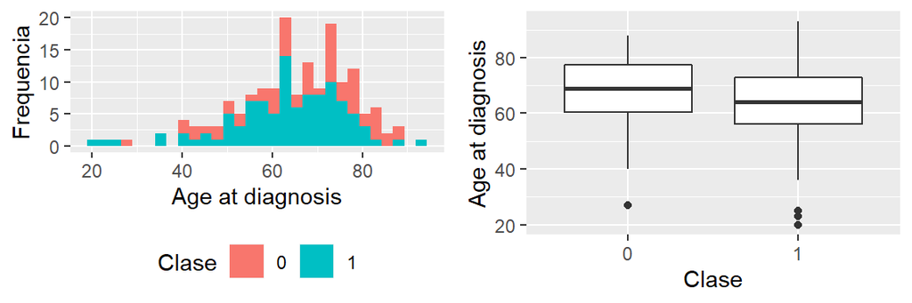

Age at diagnosis

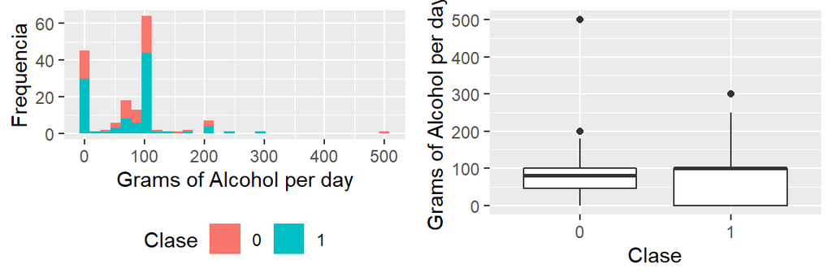

Grams of Alcohol per day

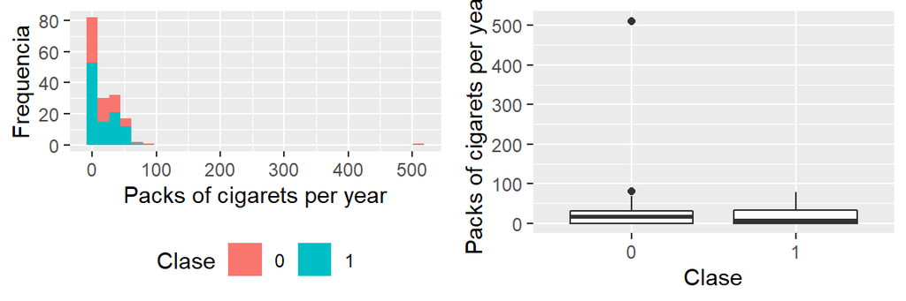

Packs of cigarets per year

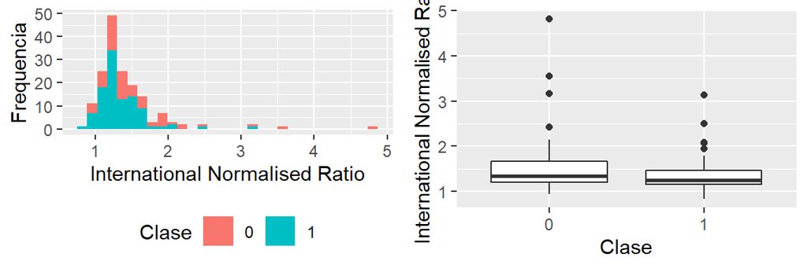

International Normalised Ratio

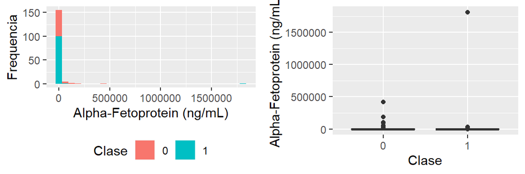

Alpha-Fetoprotein (ng/mL)

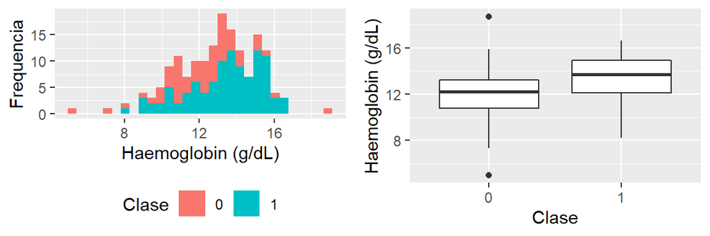

Haemoglobin (g/dL)

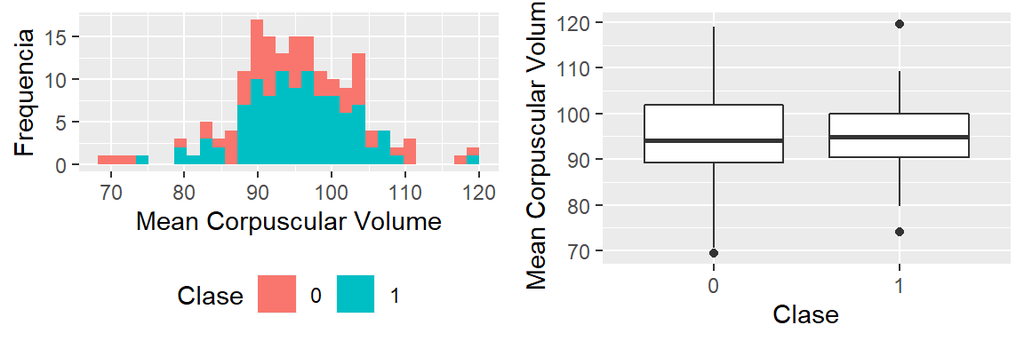

Mean Corpuscular Volume

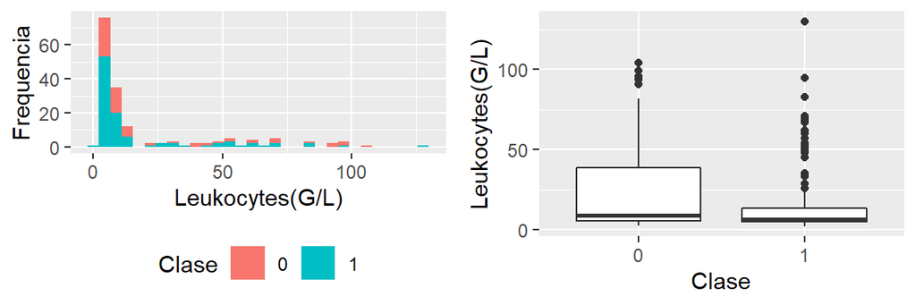

Leukocytes(G/L)

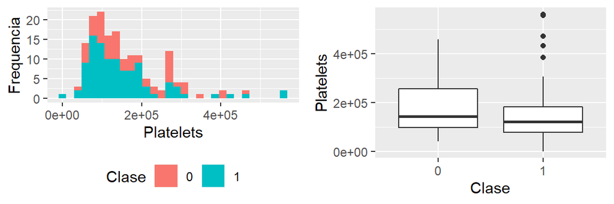

Platelets

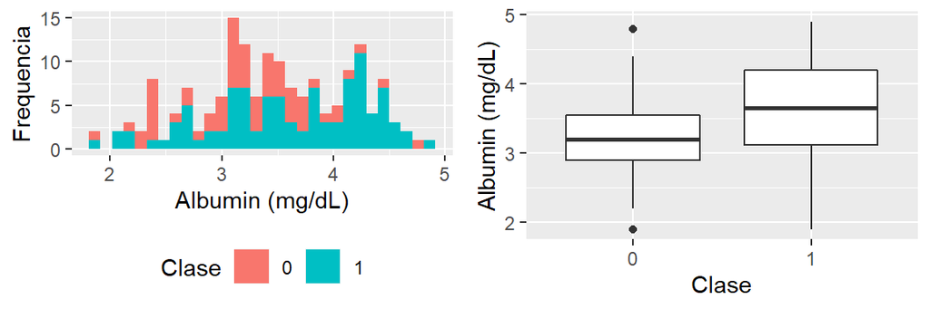

Albumin (mg/dL)

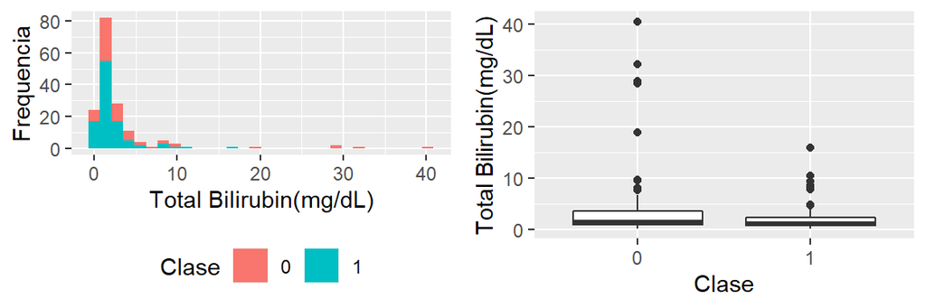

Total Bilirubin(mg/dL)

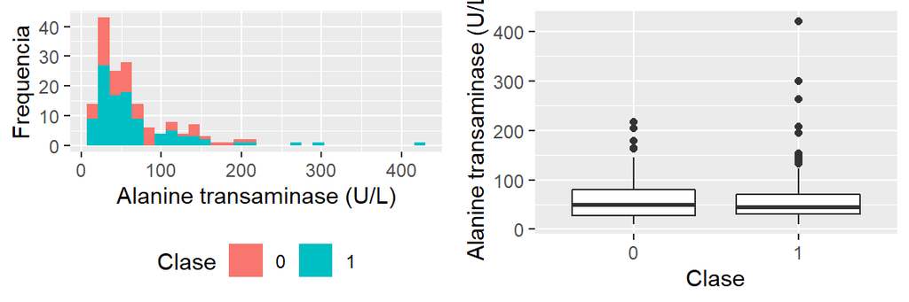

Alanine transaminase (U/L)

[11 more figures not shown]

```r
# Estudi distribució variables Numeriques
ind_CA <- which(colnames(hcc) == "Class Attribute")
figCapsNum <- names(hcc)[hcc_num]

# grafic 1 - histograma
# grafic 2 - boxplot
for (i in 1:length(hcc_num)) {
  data <- hcc[,c(hcc_num[i],ind_CA )]
  name_var <- names(data)

  a1<-data %>%
    ggplot(aes(x=data[,1], fill=`Class Attribute`))+
    geom_histogram() +
    labs(fill="Clase", y = "Frequencia", x =name_var[1] ) +
    theme(legend.position = "bottom")

  a2<-data %>%
    ggplot(aes(x=`Class Attribute`,y=data[,1])) +
    geom_boxplot() +
    labs(x = "Clase",  y = name_var[1])

  grid.arrange(a1,a2,nrow=1)
  cat('\n\n')
}
```

Crida l’atenció diverses variables amb una distribució molt desplaçada cap a valors baixos però amb valors extrems alts. Molts són valors de laboratori, i sembla que s’adapten més a distribucions logarítmiques, pel que es modificaran. Aquestes variables són:

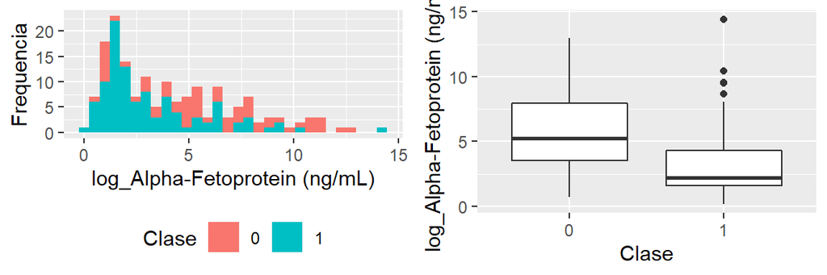

Alpha-Fetoprotein (ng/mL)

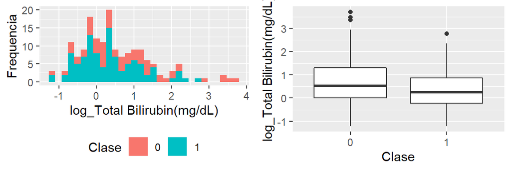

Total Bilirubin(mg/dL)

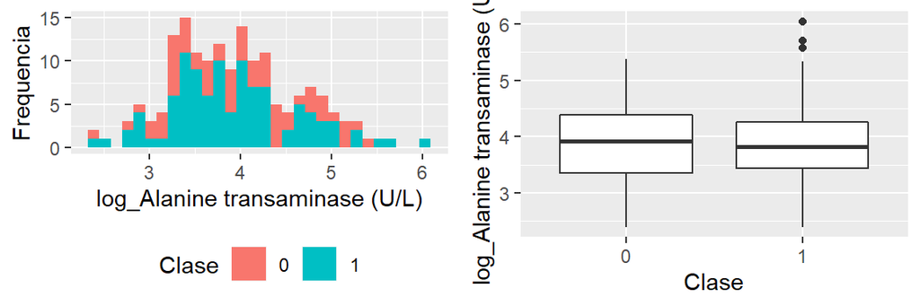

Alanine transaminase (U/L)

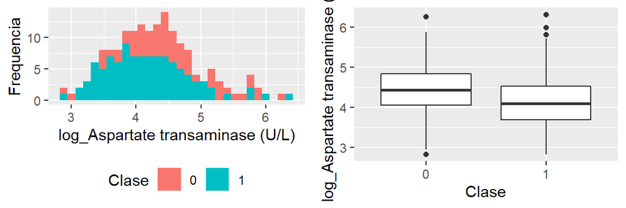

Aspartate transaminase (U/L)

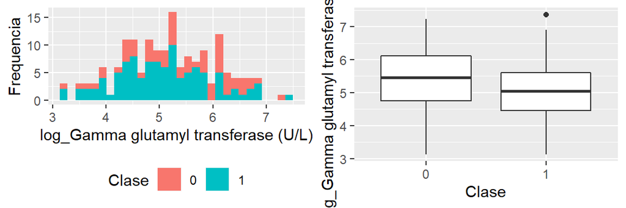

Gamma glutamyl transferase (U/L)

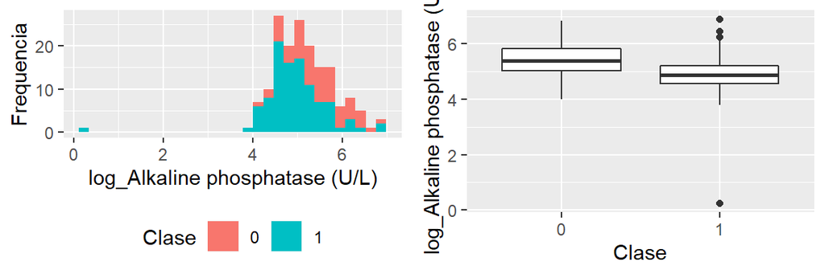

Alkaline phosphatase (U/L)

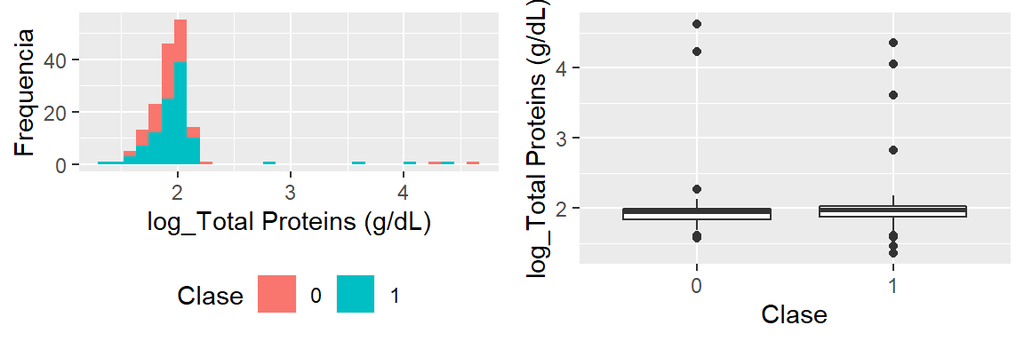

Total Proteins (g/dL)

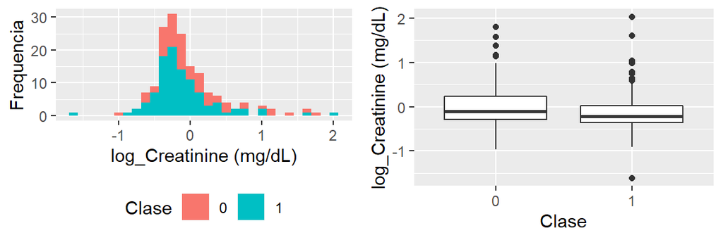

Creatinine (mg/dL)

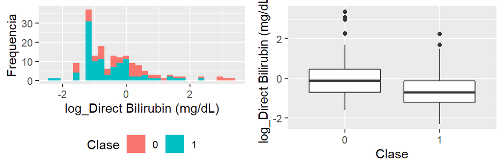

Direct Bilirubin (mg/dL)

```r
# Transformació logarítmica de variables numériques
ind_CA <- which(colnames(hcc) == "Class Attribute")
hcc_log<-c(31,37:43,46)
figCapsLog <- names(hcc)[hcc_log]

# grafic 1 - histograma
# grafic 2 - boxplot
for (i in 1:length(hcc_log)){
  #transformacio logaritimica
  hcc[,hcc_log[i]]<- log(hcc[,hcc_log[i]])
  colnames(hcc)[hcc_log[i]] <- paste("log_", colnames(hcc)[hcc_log[i]], sep = '')

  data <- hcc[,c(hcc_log[i],ind_CA )]
  name_var <- names(data)

  a1<-data %>%
    ggplot(aes(x=data[,1], fill=`Class Attribute`))+
    geom_histogram() +
    labs(fill="Clase", y = "Frequencia", x =name_var[1] ) +
    theme(legend.position = "bottom")

  a2<-data %>%
    ggplot(aes(x=`Class Attribute`,y=data[,1])) +
    geom_boxplot() +
    labs(x = "Clase",  y = name_var[1])

  grid.arrange(a1,a2,nrow=1)
  cat('\n\n')
}
```